```python
import datetime as dt
import pandas as pd
import numpy as np
import warnings
#import statsmodels.api as sm
import matplotlib.pyplot as plt
from scipy.stats import zscore
from sklearn.metrics import mean_squared_error, r2_score

warnings.filterwarnings('ignore')
```

```python
def isclose(value, original, tolerance= 0.05):
    return value <= original * (1+tolerance) and value >= original * (1-tolerance)
```

# Abstract

For this project, I chose the option of making my own trading algorithm. The algorithm in my project relies on Fourier transform to extract patterns of repetition in stock market data. The price of an asset can fluctuate around the fair price for the following reason: when buyers realize the actual price is overvalued compared to its fair, they stop buying and start selling, driving down the price; inversely, when buyers realize the actual price is undervalued compared to its fair, they stop selling and start buying, driving up the price. This behavior would translate into a harmonic motion of sorts around the fair price, and thus the algorithm can take advantage of this phenomenon.

# Methods

The dataset used for this project was the stock_data.parquet file provided for Lab 02. The algorithm is as follows:

Let’s say we have 24 days of data on a single asset's log return behind us.

1. Using the log returns from the last 24 days, we can try to extract the effective frequency that the log returns of the asset fluctuates at. To do this, we fit data points from 24 days ago until to 12 days ago with multiple periodic functions, one with period 7, one with period 8, …, and one with a period of 12 days.
2. For each of these functions:
   1. We can decide to filter out frequencies that aren't as strong as others.
   2. We need to measure how effectively it can predict the log returns within the last 12 days. To do this, the function is extended to cover the last 12 days, and the MSE metric is used to measure how closely the periodic function can predict the last 12 days.
3. We select the periodic function with the least MSE. Note that the frequency of this function is the effective frequency of oscillation within the data locally (in the last 12 days).
4. With the chosen periodic function, we can then try to predict the forward log return (the log return of the next day) by extending the periodic function into the next day. The position we have for the current day will be proportional to this predicted forward log return.

See the image below for an example of what goes on in Steps 2.1 and 2.2.

[figure not shown]

# Results

In each of the cells below is an image of the returns of the strategy along with a description of the conditions used.

1. In the Fourier analysis in Step 2.1, no frequencies were filtered out. This is virtually the same as using the raw log return data points from before 12 days ago and measuring their ability to predict the data points within the last 12 days.

[figure not shown]

2. In the Fourier analysis in Step 2.1, frequencies that had an amplitude <25% than the frequency with the maximum amplitude were filtered out.

[figure not shown]

3. In the Fourier analysis in Step 2.1, frequencies that had an amplitude <50% than the frequency with the maximum amplitude were filtered out.

[figure not shown]

4. In the Fourier analysis in Step 2.1, frequencies that had an amplitude <75% than the frequency with the maximum amplitude were filtered out.

[figure not shown]

We see that the returns get progressively worse as we filter out more and more frequencies from each selected function in Step 2.1.

I also experimented with Step 1, by trying different ranges of periods for the different periodic functions to test. I initially tried different periodic functions, with periods ranging from 7 days to 12 days. In the following trials, I also tried period ranges of 4 to 7, 5 to 9, 8 to 15, 10 to 18, 11 to 21, 13 to 24, 14 to 27, and 16 to 30. For each of the following trials, no filtering was performed in Step 2.1, as that yielded the best results for the original experiment. Note: Each period range is of the form `n` to `2n-1` or `n` to `2n-2` because there is no use in testing periods below `n`. For example, a function that has period `n-1` also has a period of `2n-2`, which is already included in the period range. Similarly, all functions with smaller periods would have been taken care of by fitting functions with periods in the interval `n` to `2n-1` or `2n-2`.

Fitting functions with period of 4 days to 7 days:

[figure not shown]

Fitting functions with period of 5 days to 9 days:

[figure not shown]

Fitting functions with period of 8 days to 15 days:

[figure not shown]

Fitting functions with period of 10 days to 18 days:

[figure not shown]

Fitting functions with period of 11 days to 21 days:

[figure not shown]

Fitting functions with period of 13 days to 24 days:

[figure not shown]

Fitting functions with period of 14 days to 27 days:

[figure not shown]

Fitting functions with period of 16 days to 30 days:

[figure not shown]

# Conclusion

In comparison to the momentum based trading strategy shown in Lab 02, this algorithm has a similar ending log return of around 0.04, and the returns seem to fluctuate less for this algorithm.

However, this algorithm doesn't perform nearly as well as the equal position strategy. The image below compares all three strategies, where my strategy is drawn in green.

[figure not shown]

# Please see my code in the section **My Strategy**

```python
# see if you can derive the transformations from log returns to simple returns, and simple returns to log returns
hdf = pd.read_parquet('/Users/ishwar/Desktop/IEOR198 Final/stock_data.parquet')
hdf.head()
```

| Price Ticker Date | Adj Close A | Adj Close AAL | Adj Close AAPL | Adj Close ABBV | Adj Close ABNB | Adj Close ABT | Adj Close ACGL | Adj Close ACN | Adj Close ADBE | Adj Close ADI | ... | Volume WTW | Volume WY | Volume WYNN | Volume XEL | Volume XOM | Volume XYL | Volume YUM | Volume ZBH | Volume ZBRA | Volume ZTS |
| --- | --- | --- | --- | --- | --- | --- | --- | --- | --- | --- | --- | --- | --- | --- | --- | --- | --- | --- | --- | --- | --- |
| 2023-10-04 | 110.917877 | 12.73 | 172.585999 | 141.069550 | 127.410004 | 93.262283 | 76.509293 | 303.237457 | 518.419983 | 170.809814 | ... | 749100 | 3954000 | 2289300 | 3948700 | 19622200 | 1614400 | 1381200 | 1597600 | 487500 | 1673400 |
| 2023-10-05 | 109.606766 | 12.85 | 173.828293 | 140.840302 | 124.989998 | 93.798546 | 77.631355 | 303.502045 | 516.440002 | 169.148819 | ... | 855000 | 3724500 | 1513600 | 3835400 | 20128800 | 1131000 | 1240200 | 1048200 | 448400 | 2083200 |
| 2023-10-06 | 109.894814 | 12.76 | 176.392334 | 141.594879 | 126.360001 | 94.461571 | 78.144844 | 305.981781 | 526.679993 | 170.986740 | ... | 897700 | 4318300 | 2470600 | 6337200 | 25363400 | 1149700 | 2111900 | 1570500 | 384000 | 1490600 |
| 2023-10-09 | 110.530510 | 12.24 | 177.883041 | 142.425888 | 127.769997 | 94.344574 | 78.040245 | 305.805359 | 529.289978 | 170.347885 | ... | 655500 | 3171800 | 1622800 | 2702100 | 22369900 | 949500 | 1840000 | 865900 | 266600 | 1215100 |
| 2023-10-10 | 112.526970 | 12.26 | 177.286758 | 142.215759 | 131.589996 | 95.124588 | 77.840553 | 306.109161 | 532.719971 | 172.952438 | ... | 478400 | 3078500 | 1674800 | 3117900 | 13892000 | 1478800 | 1643300 | 999400 | 361900 | 1665300 |

5 rows × 994 columns

```python
# use np.exp
def logtosimple(logreturn):
    return np.exp(logreturn) - 1
```

```python
# use np.log
def simpletolog(simplereturn):
    return np.log(simplereturn + 1)
```

```python
# let's look at an example asset
# create a dataframe that is just the adjusted close and volume for AAL
aal = hdf.loc[:,hdf.columns.get_level_values(1) == "AAL"]
aal.head()
```

| Price Ticker Date | Adj Close AAL | Volume AAL |
| --- | --- | --- |
| 2023-10-04 | 12.73 | 49738100 |
| 2023-10-05 | 12.85 | 36272900 |
| 2023-10-06 | 12.76 | 31822200 |
| 2023-10-09 | 12.24 | 51462700 |
| 2023-10-10 | 12.26 | 37144200 |

Let's remove the top level of the columns in order to make things easier - we already know the symbol is AAL

```python
aal.columns = aal.columns.get_level_values(0)
print(aal.columns)
aal.head()
```

```
Index(['Adj Close', 'Volume'], dtype='object', name='Price')
```

| Price Date | Adj Close | Volume |
| --- | --- | --- |
| 2023-10-04 | 12.73 | 49738100 |
| 2023-10-05 | 12.85 | 36272900 |
| 2023-10-06 | 12.76 | 31822200 |
| 2023-10-09 | 12.24 | 51462700 |
| 2023-10-10 | 12.26 | 37144200 |

To calculate returns for **AAL**, create a new column by applying `.pct_change()` to the **adjusted close** column.

```python
aal['returns'] = aal["Adj Close"].pct_change()
aal.head()
```

| Price Date | Adj Close | Volume | returns |
| --- | --- | --- | --- |
| 2023-10-04 | 12.73 | 49738100 | NaN |
| 2023-10-05 | 12.85 | 36272900 | 0.009427 |
| 2023-10-06 | 12.76 | 31822200 | -0.007004 |
| 2023-10-09 | 12.24 | 51462700 | -0.040752 |
| 2023-10-10 | 12.26 | 37144200 | 0.001634 |

```python
# we can get the log returns by adjusting the percent change function

aal['logreturns'] = aal['returns'].apply(simpletolog)
aal.head()
```

| Price Date | Adj Close | Volume | returns | logreturns |
| --- | --- | --- | --- | --- |
| 2023-10-04 | 12.73 | 49738100 | NaN | NaN |
| 2023-10-05 | 12.85 | 36272900 | 0.009427 | 0.009382 |
| 2023-10-06 | 12.76 | 31822200 | -0.007004 | -0.007029 |
| 2023-10-09 | 12.24 | 51462700 | -0.040752 | -0.041606 |
| 2023-10-10 | 12.26 | 37144200 | 0.001634 | 0.001633 |

```python
# .cumsum() on a series will add everything in the column up until that point
# this will give us the log return from the start, to the current index
aal['cum_logreturns'] = aal["logreturns"].cumsum()
aal.head()
```

| Price Date | Adj Close | Volume | returns | logreturns | cum_logreturns |
| --- | --- | --- | --- | --- | --- |
| 2023-10-04 | 12.73 | 49738100 | NaN | NaN | NaN |
| 2023-10-05 | 12.85 | 36272900 | 0.009427 | 0.009382 | 0.009382 |
| 2023-10-06 | 12.76 | 31822200 | -0.007004 | -0.007029 | 0.002354 |
| 2023-10-09 | 12.24 | 51462700 | -0.040752 | -0.041606 | -0.039252 |
| 2023-10-10 | 12.26 | 37144200 | 0.001634 | 0.001633 | -0.037619 |

```
115
```

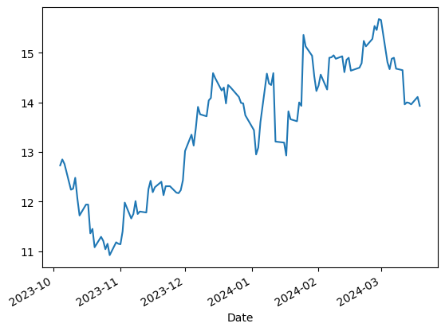

```python
# pandas also comes equipped with some built in plotting
# we can plot the adjusted close, as well as the logreturns cumsum, and see if they look the same (they should)
print(len(aal['Adj Close']))
aal['Adj Close'].plot()
```

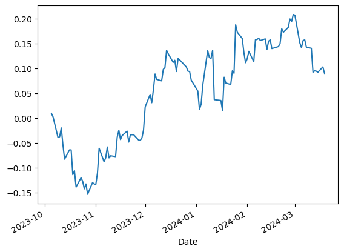

```python
aal['cum_logreturns'].plot()
```

# Basic trend strategy: long/short by percentile

### Developing a Trading Strategy

Now, let’s work on creating a **trading strategy** with the following assumptions:

- **Shorting Allowed**: We assume that we can short stocks.
- **Zero Borrowing Cost**: For simplicity, we assume the cost to borrow is **0** (note: this is a non-trivial assumption).

#### Strategy Overview

Our goal is to:

- **Buy (go long)** stocks expected to increase in value.
- **Sell (go short)** stocks expected to decrease in value.

#### Approach

1. **Ranking Stocks**:  
   We will rank stocks based on a chosen **metric** (e.g., momentum, valuation ratios, or other factors).
2. **Position Allocation**:
   - Go **long** on the top percentage of stocks ranked by the metric.
   - Go **short** on the bottom percentage of stocks ranked by the metric.

This approach allows us to systematically identify opportunities and construct a portfolio based on clear criteria.

```python
hdf
```

| Price Ticker Date | Adj Close A | Adj Close AAL | Adj Close AAPL | Adj Close ABBV | Adj Close ABNB | Adj Close ABT | Adj Close ACGL | Adj Close ACN | Adj Close ADBE | Adj Close ADI | ... | Volume WTW | Volume WY | Volume WYNN | Volume XEL | Volume XOM | Volume XYL | Volume YUM | Volume ZBH | Volume ZBRA | Volume ZTS |
| --- | --- | --- | --- | --- | --- | --- | --- | --- | --- | --- | --- | --- | --- | --- | --- | --- | --- | --- | --- | --- | --- |
| 2023-10-04 | 110.917877 | 12.73 | 172.585999 | 141.069550 | 127.410004 | 93.262283 | 76.509293 | 303.237457 | 518.419983 | 170.809814 | ... | 749100 | 3954000 | 2289300 | 3948700 | 19622200 | 1614400 | 1381200 | 1597600 | 487500 | 1673400 |
| 2023-10-05 | 109.606766 | 12.85 | 173.828293 | 140.840302 | 124.989998 | 93.798546 | 77.631355 | 303.502045 | 516.440002 | 169.148819 | ... | 855000 | 3724500 | 1513600 | 3835400 | 20128800 | 1131000 | 1240200 | 1048200 | 448400 | 2083200 |
| 2023-10-06 | 109.894814 | 12.76 | 176.392334 | 141.594879 | 126.360001 | 94.461571 | 78.144844 | 305.981781 | 526.679993 | 170.986740 | ... | 897700 | 4318300 | 2470600 | 6337200 | 25363400 | 1149700 | 2111900 | 1570500 | 384000 | 1490600 |
| 2023-10-09 | 110.530510 | 12.24 | 177.883041 | 142.425888 | 127.769997 | 94.344574 | 78.040245 | 305.805359 | 529.289978 | 170.347885 | ... | 655500 | 3171800 | 1622800 | 2702100 | 22369900 | 949500 | 1840000 | 865900 | 266600 | 1215100 |
| 2023-10-10 | 112.526970 | 12.26 | 177.286758 | 142.215759 | 131.589996 | 95.124588 | 77.840553 | 306.109161 | 532.719971 | 172.952438 | ... | 478400 | 3078500 | 1674800 | 3117900 | 13892000 | 1478800 | 1643300 | 999400 | 361900 | 1665300 |
| 2023-10-11 | 112.616356 | 12.48 | 178.688049 | 142.645569 | 130.000000 | 90.327415 | 78.943596 | 307.595276 | 549.909973 | 171.920425 | ... | 480000 | 2640400 | 2029400 | 3116400 | 57939000 | 1036300 | 1725500 | 3841300 | 822600 | 1053600 |
| 2023-10-12 | 108.206268 | 12.06 | 179.592422 | 143.070053 | 125.970001 | 88.425377 | 78.972122 | 299.544678 | 559.630005 | 170.623093 | ... | 578000 | 4219300 | 1105400 | 4775600 | 31183000 | 978500 | 1790600 | 2906600 | 597200 | 1306300 |
| 2023-10-13 | 109.765694 | 11.72 | 177.743927 | 142.742065 | 124.080002 | 89.092072 | 80.027626 | 297.054718 | 548.760010 | 168.136475 | ... | 579700 | 3614600 | 1500700 | 3732700 | 30276500 | 926300 | 1352900 | 1556600 | 460900 | 1287400 |
| 2023-10-16 | 110.749023 | 11.94 | 177.614700 | 142.037796 | 125.190002 | 90.376442 | 81.492004 | 300.509186 | 550.739990 | 169.787643 | ... | 397600 | 2912800 | 1479800 | 3184700 | 18452000 | 1003200 | 1627700 | 1284400 | 425300 | 1264400 |
| 2023-10-17 | 111.642975 | 11.94 | 176.054413 | 143.919037 | 125.709999 | 90.337219 | 82.366837 | 303.373169 | 560.090027 | 169.650040 | ... | 546100 | 3090400 | 1355000 | 3778800 | 19775400 | 1265900 | 1267500 | 1455000 | 355800 | 1716300 |
| 2023-10-18 | 107.878494 | 11.36 | 174.752518 | 144.015503 | 122.169998 | 93.690300 | 81.254280 | 298.964020 | 557.869995 | 168.333038 | ... | 557600 | 2167000 | 2029600 | 3830700 | 23380300 | 1213500 | 2039300 | 1397500 | 346400 | 1228600 |
| 2023-10-19 | 108.772430 | 11.45 | 174.374878 | 140.388107 | 119.970001 | 93.572655 | 79.666275 | 298.147186 | 555.739990 | 165.826767 | ... | 529400 | 2785600 | 2179400 | 4442300 | 20972500 | 2138200 | 1901400 | 1412200 | 517500 | 1602300 |
| 2023-10-20 | 108.494316 | 11.08 | 171.810822 | 141.073044 | 116.489998 | 94.886436 | 78.696365 | 292.301117 | 540.960022 | 163.664490 | ... | 565300 | 4143400 | 1106400 | 4224800 | 22439800 | 2774600 | 1568400 | 1294000 | 860400 | 1932000 |
| 2023-10-23 | 108.603577 | 11.29 | 171.930084 | 139.625961 | 120.389999 | 93.905998 | 77.840553 | 290.273773 | 540.409973 | 161.059937 | ... | 514700 | 3557500 | 2371400 | 4854200 | 18185000 | 1896200 | 1495700 | 1698200 | 482800 | 1075400 |
| 2023-10-24 | 104.928490 | 11.21 | 172.367386 | 141.150238 | 122.010002 | 92.954979 | 79.323952 | 291.405548 | 539.559998 | 162.101761 | ... | 494100 | 3181000 | 1335000 | 3854000 | 16786100 | 1181100 | 1246800 | 1542000 | 348200 | 1201400 |
| 2023-10-25 | 102.703583 | 11.04 | 170.041855 | 140.137253 | 118.500000 | 91.739235 | 79.390518 | 288.049500 | 521.140015 | 157.049896 | ... | 506700 | 4321800 | 1518500 | 3133100 | 22047300 | 1411800 | 985800 | 1698500 | 577900 | 1273600 |
| 2023-10-26 | 103.607452 | 11.15 | 165.857880 | 140.079391 | 115.470001 | 92.141220 | 78.401581 | 287.419586 | 514.280029 | 158.101562 | ... | 1279600 | 3988600 | 2183400 | 3468000 | 18768300 | 1155500 | 1374500 | 1197700 | 735500 | 2891100 |
| 2023-10-27 | 102.077820 | 10.92 | 167.179657 | 134.030502 | 114.089996 | 91.033325 | 77.365105 | 285.451263 | 508.119995 | 157.816528 | ... | 909100 | 3719800 | 1587500 | 4310600 | 23092000 | 1241700 | 2331000 | 1534500 | 565000 | 2407100 |
| 2023-10-30 | 100.488594 | 11.18 | 169.236847 | 136.886108 | 116.949997 | 91.180397 | 78.810471 | 288.069153 | 526.940002 | 153.206955 | ... | 621700 | 4141500 | 1343100 | 3818400 | 19379900 | 1761600 | 1551900 | 1309800 | 970000 | 2756200 |
| 2023-10-31 | 102.673782 | 11.15 | 169.713882 | 136.201141 | 118.290001 | 92.700066 | 82.423882 | 292.389709 | 532.059998 | 154.632095 | ... | 842000 | 3902400 | 1471700 | 3832300 | 22185200 | 3449200 | 2006600 | 1382000 | 914200 | 3208900 |
| 2023-11-01 | 102.167213 | 11.14 | 172.894104 | 137.445663 | 119.470001 | 93.151070 | 85.580864 | 295.883575 | 544.500000 | 156.509323 | ... | 499900 | 4240600 | 1773400 | 5029500 | 28984900 | 2128900 | 2788100 | 1503100 | 822900 | 7269900 |
| 2023-11-02 | 103.766373 | 11.40 | 176.471832 | 138.207794 | 115.500000 | 94.082474 | 81.720222 | 303.245209 | 558.710022 | 161.521866 | ... | 599000 | 4681500 | 1839800 | 3961300 | 25212700 | 1666600 | 1920500 | 3030300 | 758500 | 4137800 |
| 2023-11-03 | 108.285721 | 11.98 | 175.557526 | 136.432678 | 122.639999 | 93.964828 | 81.349373 | 308.530212 | 563.659973 | 165.040482 | ... | 911100 | 3323900 | 1866100 | 3920600 | 30549000 | 1852500 | 1754600 | 2140100 | 540800 | 1974700 |
| 2023-11-06 | 106.805763 | 11.66 | 178.121552 | 136.220428 | 118.169998 | 93.141258 | 80.978523 | 308.136566 | 565.450012 | 164.696487 | ... | 617200 | 3406900 | 2470600 | 3139700 | 19097300 | 1324300 | 1537900 | 2443700 | 373800 | 2112500 |
| 2023-11-07 | 109.795486 | 11.75 | 180.695557 | 137.146606 | 121.080002 | 92.945183 | 81.216248 | 310.203369 | 585.200012 | 165.227219 | ... | 400400 | 4216000 | 1994000 | 3515300 | 20272500 | 1385100 | 1408000 | 2699200 | 613300 | 2938200 |
| 2023-11-08 | 108.653236 | 12.01 | 181.758926 | 137.021164 | 117.660004 | 92.886345 | 79.989586 | 312.791779 | 585.309998 | 166.013519 | ... | 424600 | 3122300 | 2621400 | 3953300 | 19184100 | 1062400 | 1015300 | 1524700 | 525900 | 3326300 |
| 2023-11-09 | 107.014343 | 11.75 | 181.281906 | 133.171875 | 115.519997 | 91.719635 | 80.512573 | 309.248688 | 577.739990 | 164.264053 | ... | 907200 | 4072900 | 5825500 | 3871700 | 18380500 | 1533100 | 1096900 | 1729100 | 486900 | 3479300 |
| 2023-11-10 | 107.739441 | 11.80 | 185.491272 | 133.702469 | 118.150002 | 92.131424 | 81.729729 | 314.632141 | 597.219971 | 169.365051 | ... | 712000 | 2830900 | 15054500 | 2912100 | 17825500 | 1322000 | 1317200 | 1965900 | 602300 | 2108500 |
| 2023-11-13 | 106.736237 | 11.78 | 183.899063 | 133.750732 | 119.150002 | 93.915810 | 82.319283 | 310.636383 | 590.340027 | 167.733505 | ... | 823600 | 2991800 | 3779800 | 2960500 | 15308400 | 1261100 | 1230500 | 1702200 | 411200 | 1544900 |
| 2023-11-14 | 110.858292 | 12.25 | 186.526199 | 133.191193 | 126.680000 | 95.180557 | 81.301826 | 315.419495 | 604.330017 | 174.534836 | ... | 571800 | 4355300 | 4061300 | 4250000 | 18260500 | 1500400 | 1353700 | 1909700 | 542700 | 1421500 |

[output cut: 85 more lines]

115 rows × 994 columns

```python
# to more easily group by asset, we'll make assets into its own column using df.stack()
hdf_old = hdf.copy()
hdf = (
    hdf.stack()
    .reset_index()
    .rename(columns={'level_1': 'Symbol'})
)
hdf
```

| Price | Date | Ticker | Adj Close | Volume |
| --- | --- | --- | --- | --- |
| 0 | 2023-10-04 | A | 110.917877 | 1541700.0 |
| 1 | 2023-10-04 | AAL | 12.730000 | 49738100.0 |
| 2 | 2023-10-04 | AAPL | 172.585999 | 53020300.0 |
| 3 | 2023-10-04 | ABBV | 141.069550 | 3159600.0 |
| 4 | 2023-10-04 | ABNB | 127.410004 | 5822000.0 |
| ... | ... | ... | ... | ... |
| 57150 | 2024-03-19 | XYL | 127.775208 | 806900.0 |
| 57151 | 2024-03-19 | YUM | 135.940338 | 2266500.0 |
| 57152 | 2024-03-19 | ZBH | 125.862167 | 949300.0 |
| 57153 | 2024-03-19 | ZBRA | 285.190002 | 306000.0 |
| 57154 | 2024-03-19 | ZTS | 171.652222 | 3624000.0 |

57155 rows × 4 columns

### Calculating Returns and Log Returns

To compute **returns** and **log returns** for the entire dataset, we can **group by the ticker**, select the adjusted close column, and then use .pct_change() to get the percentage change from one row to the next

These steps will provide the necessary data to derive both simple and log returns for analysis.

```python
hdf.groupby('Ticker')['Adj Close'].pct_change()
```

```
0             NaN
1             NaN
2             NaN
3             NaN
4             NaN
           ...
57150    0.007530
57151    0.007485
57152    0.005557
57153   -0.002728
57154    0.013299
Name: Adj Close, Length: 57155, dtype: float64
```

```python
hdf['returns'] = hdf.groupby('Ticker')['Adj Close'].pct_change()
hdf.head()
```

| Price | Date | Ticker | Adj Close | Volume | returns |
| --- | --- | --- | --- | --- | --- |
| 0 | 2023-10-04 | A | 110.917877 | 1541700.0 | NaN |
| 1 | 2023-10-04 | AAL | 12.730000 | 49738100.0 | NaN |
| 2 | 2023-10-04 | AAPL | 172.585999 | 53020300.0 | NaN |
| 3 | 2023-10-04 | ABBV | 141.069550 | 3159600.0 | NaN |
| 4 | 2023-10-04 | ABNB | 127.410004 | 5822000.0 | NaN |

### Creating a Log Returns Column

To calculate log returns, we'll create a new column in the dataset. This involves applying our **simple-to-log** function to the data and assigning the results to a column named `logreturns`.

This new column will represent the log-transformed returns for each data point.

```python
hdf['logreturns'] = hdf['returns'].apply(simpletolog)
hdf.head()
```

| Price | Date | Ticker | Adj Close | Volume | returns | logreturns |
| --- | --- | --- | --- | --- | --- | --- |
| 0 | 2023-10-04 | A | 110.917877 | 1541700.0 | NaN | NaN |
| 1 | 2023-10-04 | AAL | 12.730000 | 49738100.0 | NaN | NaN |
| 2 | 2023-10-04 | AAPL | 172.585999 | 53020300.0 | NaN | NaN |
| 3 | 2023-10-04 | ABBV | 141.069550 | 3159600.0 | NaN | NaN |
| 4 | 2023-10-04 | ABNB | 127.410004 | 5822000.0 | NaN | NaN |

### Creating a Forward Log Return Column

To predict the next step of returns, we need to create a column for the **forward log return**. Here's how to do it:

1. **Group by Ticker**: Group the data by the stock ticker to ensure calculations are performed within each stock's data.
2. **Select Log Returns**: Focus on the column containing the log returns.
3. **Shift the Series**: Use `.shift(-1)` to move the series **up one row**, aligning the future return with the current row.  
   Refer to the [pandas.DataFrame.shift documentation](https://pandas.pydata.org/docs/reference/api/pandas.DataFrame.shift.html) for more details.

This process creates a new column that represents the **forward log return**, which can be used as the target variable for prediction models.

```python
hdf['fwd_logreturn'] = hdf.groupby('Ticker')['logreturns'].shift(-1)
hdf.head()
```

| Price | Date | Ticker | Adj Close | Volume | returns | logreturns | fwd_logreturn |
| --- | --- | --- | --- | --- | --- | --- | --- |
| 0 | 2023-10-04 | A | 110.917877 | 1541700.0 | NaN | NaN | -0.011891 |
| 1 | 2023-10-04 | AAL | 12.730000 | 49738100.0 | NaN | NaN | 0.009382 |
| 2 | 2023-10-04 | AAPL | 172.585999 | 53020300.0 | NaN | NaN | 0.007172 |
| 3 | 2023-10-04 | ABBV | 141.069550 | 3159600.0 | NaN | NaN | -0.001626 |
| 4 | 2023-10-04 | ABNB | 127.410004 | 5822000.0 | NaN | NaN | -0.019177 |

### Dropping Rows with NaN Values

To avoid issues in future operations, we need to drop rows where **log returns** or **forward log returns** contain `NaN` values. This can be done using the `subset` parameter in `df.dropna(subset=[])`

```python
hdf = hdf.dropna(subset=['logreturns', 'fwd_logreturn'])
hdf.head()
```

| Price | Date | Ticker | Adj Close | Volume | returns | logreturns | fwd_logreturn |
| --- | --- | --- | --- | --- | --- | --- | --- |
| 497 | 2023-10-05 | A | 109.606766 | 1295700.0 | -0.011821 | -0.011891 | 0.002625 |
| 498 | 2023-10-05 | AAL | 12.850000 | 36272900.0 | 0.009427 | 0.009382 | -0.007029 |
| 499 | 2023-10-05 | AAPL | 173.828293 | 48527900.0 | 0.007198 | 0.007172 | 0.014643 |
| 500 | 2023-10-05 | ABBV | 140.840302 | 3599500.0 | -0.001625 | -0.001626 | 0.005343 |
| 501 | 2023-10-05 | ABNB | 124.989998 | 7630200.0 | -0.018994 | -0.019177 | 0.010901 |

# Momentum

### Ranking Returns by Asset

To develop a strategy, we can **rank the returns** for each asset. But first, we need to decide:

**What metric should we use for ranking?**

#### Observations:

- **Momentum Tendency**:  
  We might guess that stocks that have **gone up** tend to continue rising, while stocks that have **gone down** tend to keep falling.

#### Why Might This Happen?

This behavior makes economic sense:

- A stock that has risen significantly might attract buyers who want to **join the trend**, driving the price higher.
- Conversely, a stock that has fallen may face additional selling pressure from investors exiting their positions.

### Calculating Ranks Using `.rank()`

To calculate ranks for log returns, we can use the `.rank()` method. This method assigns a rank value as if the DataFrame were sorted. Key steps:

1. **Descending Order**: Use `ascending=False` to rank in descending order.
2. **Dense Ranking**: Specify `method='dense'` to ensure that ranks are consecutive even when there are ties.
3. **Group by Date**: Group the data by date to calculate ranks within each group.
4. **Assign to a New Column**: Create a new column, `logreturn_rank`, to store the ranks of the `logreturns` column.

Refer to the [pandas.DataFrame.rank documentation](https://pandas.pydata.org/docs/reference/api/pandas.DataFrame.rank.html) for more details.

```python
hdf['logreturn_rank'] = hdf.groupby('Date')['logreturns'].rank(ascending=False, method='dense')
hdf.head()
```

| Price | Date | Ticker | Adj Close | Volume | returns | logreturns | fwd_logreturn | logreturn_rank |
| --- | --- | --- | --- | --- | --- | --- | --- | --- |
| 497 | 2023-10-05 | A | 109.606766 | 1295700.0 | -0.011821 | -0.011891 | 0.002625 | 392.0 |
| 498 | 2023-10-05 | AAL | 12.850000 | 36272900.0 | 0.009427 | 0.009382 | -0.007029 | 71.0 |
| 499 | 2023-10-05 | AAPL | 173.828293 | 48527900.0 | 0.007198 | 0.007172 | 0.014643 | 99.0 |
| 500 | 2023-10-05 | ABBV | 140.840302 | 3599500.0 | -0.001625 | -0.001626 | 0.005343 | 242.0 |
| 501 | 2023-10-05 | ABNB | 124.989998 | 7630200.0 | -0.018994 | -0.019177 | 0.010901 | 443.0 |

```python
pd.set_option('display.max_rows', 200)
#hdf.groupby('Ticker').get_group("AAL")
hdf.groupby('Date').get_group("2023-10-05").sort_values(by=['logreturn_rank'])
```

| Price | Date | Ticker | Adj Close | Volume | returns | logreturns | fwd_logreturn | logreturn_rank |
| --- | --- | --- | --- | --- | --- | --- | --- | --- |
| 786 | 2023-10-05 | LW | 95.649353 | 7554600.0 | 0.080230 | 0.077174 | -0.044773 | 1.0 |
| 804 | 2023-10-05 | MKTX | 222.038803 | 787600.0 | 0.057811 | 0.056202 | 0.056525 | 2.0 |
| 613 | 2023-10-05 | CSGP | 79.489998 | 2578700.0 | 0.040037 | 0.039256 | 0.014364 | 3.0 |
| 663 | 2023-10-05 | EQT | 40.214714 | 6080000.0 | 0.036318 | 0.035674 | 0.040540 | 4.0 |
| 835 | 2023-10-05 | NRG | 37.469059 | 4142300.0 | 0.032835 | 0.032307 | 0.007211 | 5.0 |
| ... | ... | ... | ... | ... | ... | ... | ... | ... |
| 768 | 2023-10-05 | KO | 50.808578 | 29878100.0 | -0.048329 | -0.049535 | 0.014405 | 493.0 |
| 861 | 2023-10-05 | PEP | 155.269150 | 10556400.0 | -0.052158 | -0.053567 | 0.001186 | 494.0 |
| 592 | 2023-10-05 | CLX | 119.689247 | 7595500.0 | -0.052340 | -0.053760 | 0.000560 | 495.0 |
| 797 | 2023-10-05 | MDLZ | 63.479565 | 7626600.0 | -0.052563 | -0.053994 | -0.026631 | 496.0 |
| 925 | 2023-10-05 | TAP | 57.288155 | 3523000.0 | -0.062986 | -0.065057 | 0.002368 | 497.0 |

497 rows × 8 columns

```python
# we can also look at the demeaned returns, or the returns of the asset we chose relative to all assets
# this will help us assess if we were able to choose the assets that would end up under/overperforming

date_mean_logreturns = hdf.groupby('Date')['logreturns'].transform('mean')

# Calculate the demeaned log returns
hdf['demeaned_logreturn'] = hdf['logreturns'] - date_mean_logreturns

# Similar to the above, calculate the mean *forward* log returns for each date
date_mean_fwd_logreturns = hdf.groupby('Date')['fwd_logreturn'].transform('mean')

# Calculate the demeaned forward log returns
hdf['demeaned_fwd_logreturn'] = hdf['fwd_logreturn'] - date_mean_fwd_logreturns
hdf.head()
```

| Price | Date | Ticker | Adj Close | Volume | returns | logreturns | fwd_logreturn | logreturn_rank | demeaned_logreturn | demeaned_fwd_logreturn |
| --- | --- | --- | --- | --- | --- | --- | --- | --- | --- | --- |
| 497 | 2023-10-05 | A | 109.606766 | 1295700.0 | -0.011821 | -0.011891 | 0.002625 | 392.0 | -0.008552 | -0.005998 |
| 498 | 2023-10-05 | AAL | 12.850000 | 36272900.0 | 0.009427 | 0.009382 | -0.007029 | 71.0 | 0.012721 | -0.015651 |
| 499 | 2023-10-05 | AAPL | 173.828293 | 48527900.0 | 0.007198 | 0.007172 | 0.014643 | 99.0 | 0.010511 | 0.006020 |
| 500 | 2023-10-05 | ABBV | 140.840302 | 3599500.0 | -0.001625 | -0.001626 | 0.005343 | 242.0 | 0.001712 | -0.003279 |
| 501 | 2023-10-05 | ABNB | 124.989998 | 7630200.0 | -0.018994 | -0.019177 | 0.010901 | 443.0 | -0.015838 | 0.002279 |

```python
# for ease of analyzing the effect, we will bucket our feature using a decile (each bin is 10%-ile)
# this will help us figure out how strong the effect is
# we do this using pd.qcut(x, q=quantile, labels=False, duplicates='drop'), which cuts a series into quantile buckets. pass q=10 to get decile buckets
# [https://pandas.pydata.org/docs/reference/api/pandas.qcut.html]
# drop labels and duplicates
hdf['logreturn_decile'] = hdf.groupby('Date')['logreturns'].transform(
    lambda x: pd.qcut(x, q=10, labels=False, duplicates='drop'))
hdf.head()
```

| Price | Date | Ticker | Adj Close | Volume | returns | logreturns | fwd_logreturn | logreturn_rank | demeaned_logreturn | demeaned_fwd_logreturn | logreturn_decile |
| --- | --- | --- | --- | --- | --- | --- | --- | --- | --- | --- | --- |
| 497 | 2023-10-05 | A | 109.606766 | 1295700.0 | -0.011821 | -0.011891 | 0.002625 | 392.0 | -0.008552 | -0.005998 | 2 |
| 498 | 2023-10-05 | AAL | 12.850000 | 36272900.0 | 0.009427 | 0.009382 | -0.007029 | 71.0 | 0.012721 | -0.015651 | 8 |
| 499 | 2023-10-05 | AAPL | 173.828293 | 48527900.0 | 0.007198 | 0.007172 | 0.014643 | 99.0 | 0.010511 | 0.006020 | 8 |
| 500 | 2023-10-05 | ABBV | 140.840302 | 3599500.0 | -0.001625 | -0.001626 | 0.005343 | 242.0 | 0.001712 | -0.003279 | 5 |
| 501 | 2023-10-05 | ABNB | 124.989998 | 7630200.0 | -0.018994 | -0.019177 | 0.010901 | 443.0 | -0.015838 | 0.002279 | 1 |

```python
hdf.groupby('logreturn_decile').mean(numeric_only = True)['demeaned_fwd_logreturn']
```

```
logreturn_decile
0    0.000197
1    0.000603
2    0.000219
3   -0.000012
4    0.000123
5    0.000040
6   -0.000063
7   -0.000205
8   -0.000251
9   -0.000650
Name: demeaned_fwd_logreturn, dtype: float64
```

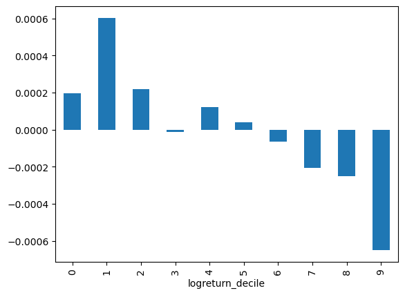

```python
# we'll plot this using a barplot
hdf.groupby('logreturn_decile').mean(numeric_only = True)['demeaned_fwd_logreturn'].plot(kind='bar')
```

```python
# it definitely looks like the bottom and top 20%-ile have outsized returns!
```

# Strategy 'backtesting'

### Backtesting: A Simplified Approach

While backtesting is a valuable tool, it can sometimes be excessive when conducting an **initial test** to evaluate whether a feature is useful. Instead, we’ll start with a **basic backtest** using the following assumptions:

1. **No Trading Costs**:
   - We'll ignore trading costs for now.
   - Although trading costs are a significant drag on profitability, they're not critical for this initial test.
2. **Key Idea**:
   - If a strategy **doesn’t work** without trading costs, it’s unlikely to work **with** trading costs included.

This simplified backtest provides a quick way to assess the viability of features before diving into more complex analyses.

```python
# let's define our strategy by setting an asset to be long or short if its in the top or bottom 20% log return decile
# we'll also equal weight all our positions
# the decile values for the bottom 20% would be 0 and 1
# the decile values for the top 20% would be 8 and 9

# we can use np.where() in order to conditionally assign a column
def longorshort(d):
    if d in [0, 1]:
        return 1
    elif d in [8, 9]:
        return -1
    else:
        return 0
hdf['long/short'] = hdf["logreturn_decile"].apply(longorshort)
hdf.head()
```

| Price | Date | Ticker | Adj Close | Volume | returns | logreturns | fwd_logreturn | logreturn_rank | demeaned_logreturn | demeaned_fwd_logreturn | logreturn_decile | long/short |
| --- | --- | --- | --- | --- | --- | --- | --- | --- | --- | --- | --- | --- |
| 497 | 2023-10-05 | A | 109.606766 | 1295700.0 | -0.011821 | -0.011891 | 0.002625 | 392.0 | -0.008552 | -0.005998 | 2 | 0 |
| 498 | 2023-10-05 | AAL | 12.850000 | 36272900.0 | 0.009427 | 0.009382 | -0.007029 | 71.0 | 0.012721 | -0.015651 | 8 | -1 |
| 499 | 2023-10-05 | AAPL | 173.828293 | 48527900.0 | 0.007198 | 0.007172 | 0.014643 | 99.0 | 0.010511 | 0.006020 | 8 | -1 |
| 500 | 2023-10-05 | ABBV | 140.840302 | 3599500.0 | -0.001625 | -0.001626 | 0.005343 | 242.0 | 0.001712 | -0.003279 | 5 | 0 |
| 501 | 2023-10-05 | ABNB | 124.989998 | 7630200.0 | -0.018994 | -0.019177 | 0.010901 | 443.0 | -0.015838 | 0.002279 | 1 | 1 |

```python
# we size our positions by taking our absolute long/short position
hdf['absposition'] = np.abs(hdf["long/short"])
hdf.head()
```

| Price | Date | Ticker | Adj Close | Volume | returns | logreturns | fwd_logreturn | logreturn_rank | demeaned_logreturn | demeaned_fwd_logreturn | logreturn_decile | long/short | absposition |
| --- | --- | --- | --- | --- | --- | --- | --- | --- | --- | --- | --- | --- | --- |
| 497 | 2023-10-05 | A | 109.606766 | 1295700.0 | -0.011821 | -0.011891 | 0.002625 | 392.0 | -0.008552 | -0.005998 | 2 | 0 | 0 |
| 498 | 2023-10-05 | AAL | 12.850000 | 36272900.0 | 0.009427 | 0.009382 | -0.007029 | 71.0 | 0.012721 | -0.015651 | 8 | -1 | 1 |
| 499 | 2023-10-05 | AAPL | 173.828293 | 48527900.0 | 0.007198 | 0.007172 | 0.014643 | 99.0 | 0.010511 | 0.006020 | 8 | -1 | 1 |
| 500 | 2023-10-05 | ABBV | 140.840302 | 3599500.0 | -0.001625 | -0.001626 | 0.005343 | 242.0 | 0.001712 | -0.003279 | 5 | 0 | 0 |
| 501 | 2023-10-05 | ABNB | 124.989998 | 7630200.0 | -0.018994 | -0.019177 | 0.010901 | 443.0 | -0.015838 | 0.002279 | 1 | 1 | 1 |

```python
# getting the total number of our positions by summing our absolute position for each day
# hint: take a look at .transform documentation [https://pandas.pydata.org/docs/reference/api/pandas.DataFrame.transform.html]
hdf['numpositions'] = hdf.groupby('Date')['absposition'].transform('sum')
hdf.head()
```

| Price | Date | Ticker | Adj Close | Volume | returns | logreturns | fwd_logreturn | logreturn_rank | demeaned_logreturn | demeaned_fwd_logreturn | logreturn_decile | long/short | absposition | numpositions |
| --- | --- | --- | --- | --- | --- | --- | --- | --- | --- | --- | --- | --- | --- | --- |
| 497 | 2023-10-05 | A | 109.606766 | 1295700.0 | -0.011821 | -0.011891 | 0.002625 | 392.0 | -0.008552 | -0.005998 | 2 | 0 | 0 | 200 |
| 498 | 2023-10-05 | AAL | 12.850000 | 36272900.0 | 0.009427 | 0.009382 | -0.007029 | 71.0 | 0.012721 | -0.015651 | 8 | -1 | 1 | 200 |
| 499 | 2023-10-05 | AAPL | 173.828293 | 48527900.0 | 0.007198 | 0.007172 | 0.014643 | 99.0 | 0.010511 | 0.006020 | 8 | -1 | 1 | 200 |
| 500 | 2023-10-05 | ABBV | 140.840302 | 3599500.0 | -0.001625 | -0.001626 | 0.005343 | 242.0 | 0.001712 | -0.003279 | 5 | 0 | 0 | 200 |
| 501 | 2023-10-05 | ABNB | 124.989998 | 7630200.0 | -0.018994 | -0.019177 | 0.010901 | 443.0 | -0.015838 | 0.002279 | 1 | 1 | 1 | 200 |

```python
# and we get our final weight for each asset by scaling our long/short indicator variable by the number of positions we have
# each position should be such that we add up to one, so we'd divide the indicator by total positions
# if we have 0 positions, the weight should be 0
# this will mean that we should have equal size long and short, adding up to a total of 1 (no leverage)
# we'll use df.apply(lambda row: (expression using row) if (condition on some row) else value, axis=1)

hdf['weight'] = hdf['long/short'] / hdf['numpositions']
hdf.head()
```

| Price | Date | Ticker | Adj Close | Volume | returns | logreturns | fwd_logreturn | logreturn_rank | demeaned_logreturn | demeaned_fwd_logreturn | logreturn_decile | long/short | absposition | numpositions | weight |
| --- | --- | --- | --- | --- | --- | --- | --- | --- | --- | --- | --- | --- | --- | --- | --- |
| 497 | 2023-10-05 | A | 109.606766 | 1295700.0 | -0.011821 | -0.011891 | 0.002625 | 392.0 | -0.008552 | -0.005998 | 2 | 0 | 0 | 200 | 0.000 |
| 498 | 2023-10-05 | AAL | 12.850000 | 36272900.0 | 0.009427 | 0.009382 | -0.007029 | 71.0 | 0.012721 | -0.015651 | 8 | -1 | 1 | 200 | -0.005 |
| 499 | 2023-10-05 | AAPL | 173.828293 | 48527900.0 | 0.007198 | 0.007172 | 0.014643 | 99.0 | 0.010511 | 0.006020 | 8 | -1 | 1 | 200 | -0.005 |
| 500 | 2023-10-05 | ABBV | 140.840302 | 3599500.0 | -0.001625 | -0.001626 | 0.005343 | 242.0 | 0.001712 | -0.003279 | 5 | 0 | 0 | 200 | 0.000 |
| 501 | 2023-10-05 | ABNB | 124.989998 | 7630200.0 | -0.018994 | -0.019177 | 0.010901 | 443.0 | -0.015838 | 0.002279 | 1 | 1 | 1 | 200 | 0.005 |

```python
# finally we define the strategy's return as the weighted logreturns based on our position
# so we multiply weight by forward logreturn
hdf['strategy_logreturn'] = hdf['weight'] * hdf['fwd_logreturn']
hdf.head()
```

| Price | Date | Ticker | Adj Close | Volume | returns | logreturns | fwd_logreturn | logreturn_rank | demeaned_logreturn | demeaned_fwd_logreturn | logreturn_decile | long/short | absposition | numpositions | weight | strategy_logreturn |
| --- | --- | --- | --- | --- | --- | --- | --- | --- | --- | --- | --- | --- | --- | --- | --- | --- |
| 497 | 2023-10-05 | A | 109.606766 | 1295700.0 | -0.011821 | -0.011891 | 0.002625 | 392.0 | -0.008552 | -0.005998 | 2 | 0 | 0 | 200 | 0.000 | 0.000000 |
| 498 | 2023-10-05 | AAL | 12.850000 | 36272900.0 | 0.009427 | 0.009382 | -0.007029 | 71.0 | 0.012721 | -0.015651 | 8 | -1 | 1 | 200 | -0.005 | 0.000035 |
| 499 | 2023-10-05 | AAPL | 173.828293 | 48527900.0 | 0.007198 | 0.007172 | 0.014643 | 99.0 | 0.010511 | 0.006020 | 8 | -1 | 1 | 200 | -0.005 | -0.000073 |
| 500 | 2023-10-05 | ABBV | 140.840302 | 3599500.0 | -0.001625 | -0.001626 | 0.005343 | 242.0 | 0.001712 | -0.003279 | 5 | 0 | 0 | 200 | 0.000 | 0.000000 |
| 501 | 2023-10-05 | ABNB | 124.989998 | 7630200.0 | -0.018994 | -0.019177 | 0.010901 | 443.0 | -0.015838 | 0.002279 | 1 | 1 | 1 | 200 | 0.005 | 0.000055 |

```python
# we can compare this with an equal weighted strategy, where we long each asset the same amount, again summing up to 1
# hint: use .unique() to get number of assets [https://pandas.pydata.org/docs/reference/api/pandas.unique.html]

hdf['eqweight'] = 1 / len(pd.unique(hdf['Ticker']))
hdf['equal_logreturn'] = hdf['eqweight'] * hdf['fwd_logreturn']
hdf.head()
```

| Price | Date | Ticker | Adj Close | Volume | returns | logreturns | fwd_logreturn | logreturn_rank | demeaned_logreturn | demeaned_fwd_logreturn | logreturn_decile | long/short | absposition | numpositions | weight | strategy_logreturn | eqweight | equal_logreturn |
| --- | --- | --- | --- | --- | --- | --- | --- | --- | --- | --- | --- | --- | --- | --- | --- | --- | --- | --- |
| 497 | 2023-10-05 | A | 109.606766 | 1295700.0 | -0.011821 | -0.011891 | 0.002625 | 392.0 | -0.008552 | -0.005998 | 2 | 0 | 0 | 200 | 0.000 | 0.000000 | 0.002012 | 0.000005 |
| 498 | 2023-10-05 | AAL | 12.850000 | 36272900.0 | 0.009427 | 0.009382 | -0.007029 | 71.0 | 0.012721 | -0.015651 | 8 | -1 | 1 | 200 | -0.005 | 0.000035 | 0.002012 | -0.000014 |
| 499 | 2023-10-05 | AAPL | 173.828293 | 48527900.0 | 0.007198 | 0.007172 | 0.014643 | 99.0 | 0.010511 | 0.006020 | 8 | -1 | 1 | 200 | -0.005 | -0.000073 | 0.002012 | 0.000029 |
| 500 | 2023-10-05 | ABBV | 140.840302 | 3599500.0 | -0.001625 | -0.001626 | 0.005343 | 242.0 | 0.001712 | -0.003279 | 5 | 0 | 0 | 200 | 0.000 | 0.000000 | 0.002012 | 0.000011 |
| 501 | 2023-10-05 | ABNB | 124.989998 | 7630200.0 | -0.018994 | -0.019177 | 0.010901 | 443.0 | -0.015838 | 0.002279 | 1 | 1 | 1 | 200 | 0.005 | 0.000055 | 0.002012 | 0.000022 |

# Evaluating performance

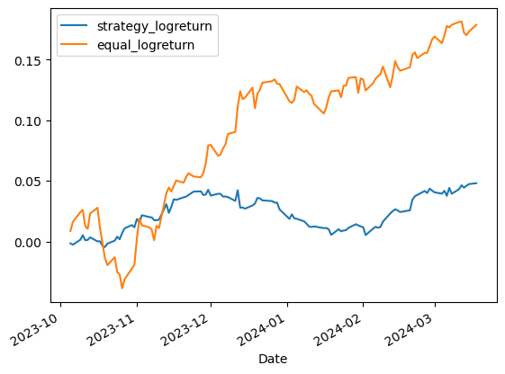

```python
hdf.groupby('Date').sum()['strategy_logreturn'].cumsum().plot(legend=True)
hdf.groupby('Date').sum()['equal_logreturn'].cumsum().plot(legend=True)
```

```python
# we can get the final return by getting the last value of the column (values[-1])
# and we can translate that to simple returns for readability
final_strategyreturn = logtosimple(hdf.groupby('Date').sum()['strategy_logreturn'].cumsum().values[-1])
final_equalreturn = logtosimple(hdf.groupby('Date').sum()['equal_logreturn'].cumsum().values[-1])

print(f'final_strategyreturn: {final_strategyreturn}')
print(f'final_equalreturn: {final_equalreturn}')
```

```
final_strategyreturn: 0.04924253346870078
final_equalreturn: 0.19573618511585034
```

### Evaluating Strategy Performance

The equal-weight strategy significantly outperformed our strategy. Given the simplicity of our approach, this outcome is not unexpected. However, the equal-weight strategy also exhibited notable **volatility**.

To better account for volatility, we can use the **Sharpe Ratio**.

#### Understanding the Sharpe Ratio

The Sharpe Ratio measures the **risk-adjusted return** of a strategy and can be thought of as a t-test for the statistical significance of the returns. It is calculated as:

$$ \text{Sharpe Ratio} = \frac{\text{Mean Return} - \text{Risk-Free Rate}}{\text{Standard Deviation of Returns}}$$

Benerally, any sharpe ratio over 1 is good, 2 is very good, 3+ is very very good. As you see a sharpe ratio > 3, the more likely that the strategy is somehow limited, or you've calculated something wrong

#### Important Caveats

In this example, the calculated Sharpe Ratios are **not realistic** due to several simplifications. For instance:

- **Lookahead Bias**: Restricting the universe to companies currently in the S&P 500 introduces bias, as we are using information unavailable in past periods (e.g., in 2023).

There are likely other ways this sample or testing strategy might be limited. Consider exploring additional potential biases or flaws in the approach!

```python
# let's calculate the sharpe ratio with a function, we'll leave out the risk free rate part of it for now
# we also need to normalize the sharpe ratio with respect to a year, by multiplying by the square root of periods our strategy trades in a year
# note that there are 252 trading days

def sharpe_ratio(mean_ret, std_ret):
    return (mean_ret / std_ret) * np.sqrt(252)

strat_sharpe = sharpe_ratio(hdf.groupby('Date').sum()['strategy_logreturn'].mean(), \
            hdf.groupby('Date').sum()['strategy_logreturn'].std())
equal_sharpe = sharpe_ratio(hdf.groupby('Date').sum()['equal_logreturn'].mean(), \
            hdf.groupby('Date').sum()['equal_logreturn'].std())
print(strat_sharpe, equal_sharpe)
```

```
1.840395868545438 3.1044873685151626
```

# My Strategy: Fourier analysis on log returns

```python
# take a single asset
# take the list of log returns associated with the asset
aapl = hdf.groupby("Ticker").get_group("EQR")["logreturns"]
#aapl = aapl[0:len(aapl)//2]
aapl = aapl.to_numpy()
# plot it

# take the first half and perform fft
def perform_fft(sequence):
    # Perform the Fast Fourier Transform
    fft_result = np.fft.fft(sequence)
    # Compute the corresponding frequencies
    n = len(sequence)
    freq = np.fft.fftfreq(n)
    return freq, fft_result
def recover_signal(fft_result):
    # Perform the Inverse Fast Fourier Transform to recover the original signal
    recovered_signal = np.fft.ifft(fft_result)
    return np.real(recovered_signal)  # Return only the real part (original signal)
def extrapolate_signal(fft_result, num_points):
    # Extend the FFT result by zero-padding to extrapolate the time series
    n = len(fft_result)
    extended_fft = np.zeros(num_points, dtype=complex)
    extended_fft[:n] = fft_result

    # Perform the inverse FFT on the extended data
    extrapolated_signal = np.fft.ifft(extended_fft)
    return np.real(extrapolated_signal)  # Return only the real part

"""
window_len = 24
freq, fft_result = perform_fft(aapl[:window_len])
fft_result[7:len(aapl)-7] = 0
#print(fft_result)
#print(freq)
aapl_fourier = recover_signal(fft_result)

plt.plot(range(0, len(aapl_fourier))[:window_len], aapl[:window_len])
print(len(aapl))
plt.plot(range(0, len(aapl_fourier))[:window_len], aapl_fourier[:window_len])
plt.legend(loc="upper right")
plt.show()

plt.plot(range(0, len(aapl)), aapl)
print(len(aapl) // window_len)
#print(np.concatenate(2 * (aapl_fourier,)))
plt.plot(range(0, len(aapl)), np.concatenate((1 + len(aapl)//window_len)*(aapl_fourier,))[0:len(aapl)] )
plt.legend(loc="upper right")
plt.show()
"""

"""
plt.plot(freq[:len(freq)//2], np.abs(fft_result)[:len(freq)//2])
plt.title("FFT Result (Magnitude)")
plt.xlabel("Frequency")
plt.ylabel("Magnitude")
plt.show()
"""
# plot the waveform from the fft onto the full data and see if there is any predictive power
```

```
'\nplt.plot(freq[:len(freq)//2], np.abs(fft_result)[:len(freq)//2])\nplt.title("FFT Result (Magnitude)")\nplt.xlabel("Frequency")\nplt.ylabel("Magnitude")\nplt.show()\n'
```

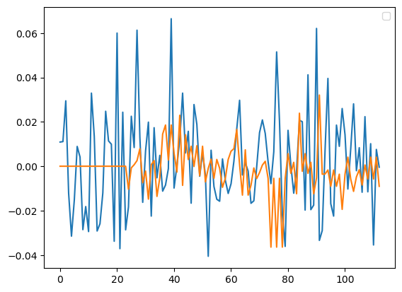

```python
# eliminate high frequency components with wavelength <= 3
"""
cutoff_wavelength = 5
cutoff_freq = 1/cutoff_wavelength
cutoff_n = l // cutoff_wavelength
fft_result[:cutoff_n:] = 0
fft_result[l-cutoff_n:] = 0
"""

def predict_fwd_logreturn(windowed_series):
    window_lens = range(12, 6, -1)
    test_len = 12
    mses = []
    ls = []
    signals = []
    for l in window_lens:
        # perform fft on a window of length l, excluding 5 data points after it
        to_fit = windowed_series[-l-test_len:-test_len]
        freq, fft_result = perform_fft(to_fit)

        # remove insignificant frequency components
        #max_amp = np.max(np.abs(fft_result))
        #fft_result[np.abs(fft_result) < max_amp * 0.625] = 0

        # reconstruct original signal
        lowpass_signal = recover_signal(fft_result)

        extended_signal = np.concatenate(((l+test_len+1+ l) // l)*(lowpass_signal,))[:l+test_len+1] # extend lowpass_signal to include next 5 days and the 6th day to be predicted
        #print(l)
        #print(len(extended_signal))

        # measure how close the last 5 data points match up with the first 5 values of the lowpass signal
        mse = np.mean(np.square(extended_signal[-test_len-1:-1] - windowed_series[-test_len:]))
        mses.append(mse)
        ls.append(l)
        signals.append(extended_signal)

    # find effective frequency of data points
    min_error = 1e9
    min_i = -1
    for i in range(len(mses)):
        if mses[i] < min_error:
            min_error = mses[i]
            min_i = i

    #print("Freq: ", ls[min_i])
    #plt.plot(range(ls[min_i]+test_len), windowed_series[-ls[min_i]-test_len:])
    #plt.plot(range(ls[min_i]+test_len), signals[min_i][:-1])
    #plt.legend(loc="upper right")
    #plt.show()

    return signals[min_i][-1]

# assumed for one asset
def calculate_positions(single_asset):
    #g = data.groupby('Ticker')
    #tickers = g.groups.keys()
    #print(tickers)
    #grp_name = "AAPL"
    #single_asset = g.get_group(grp_name)

    fwds_list = np.zeros(single_asset.shape[0])
    window_len = 24
    for i in range(window_len, len(fwds_list)):
        #print(f"Day {i}")
        window_logreturns = single_asset[i-window_len:i].to_numpy()
        #pstn = calculate_single_position(window_logreturns)
        fwd = predict_fwd_logreturn(window_logreturns)
        fwds_list[i] = fwd
    #print(positions)
    return fwds_list

asset_fwdlogreturns = hdf.groupby("Ticker").get_group("ABNB")["fwd_logreturn"]
asset_fwd = calculate_positions(hdf.groupby("Ticker").get_group("AAPL")["logreturns"])

plt.plot(range(0, len(asset_fwdlogreturns)), asset_fwdlogreturns)
plt.plot(range(0, len(asset_fwdlogreturns)), asset_fwd)
plt.legend(loc="upper right")
plt.show()

#hdf["newstrat_longshort"] = hdf.groupby("Ticker")["logreturns"].transform(calculate_positions)
```

```python
hdf["newstrat_predictedlogret"] = hdf.groupby("Ticker")["logreturns"].transform(calculate_positions)
```

```python
hdf.tail(10)
```

| Price | Date | Ticker | Adj Close | Volume | returns | logreturns | fwd_logreturn | logreturn_rank | demeaned_logreturn | demeaned_fwd_logreturn | logreturn_decile | long/short | absposition | numpositions | weight | strategy_logreturn | eqweight | equal_logreturn | newstrat_predictedlogret |
| --- | --- | --- | --- | --- | --- | --- | --- | --- | --- | --- | --- | --- | --- | --- | --- | --- | --- | --- | --- |
| 56648 | 2024-03-18 | WTW | 271.214355 | 402800.0 | 0.006876 | 0.006853 | -0.003219 | 149.0 | 0.003870 | -0.008853 | 7 | 0 | 0 | 200 | 0.000 | -0.000000 | 0.002012 | -0.000006 | -0.002325 |
| 56649 | 2024-03-18 | WY | 33.697689 | 3373100.0 | -0.005243 | -0.005257 | 0.011066 | 401.0 | -0.008240 | 0.005432 | 1 | 1 | 1 | 200 | 0.005 | 0.000055 | 0.002012 | 0.000022 | 0.003654 |
| 56650 | 2024-03-18 | WYNN | 97.998962 | 1528700.0 | -0.002523 | -0.002526 | 0.009165 | 360.0 | -0.005509 | 0.003531 | 2 | 0 | 0 | 200 | 0.000 | 0.000000 | 0.002012 | 0.000018 | -0.008268 |
| 56651 | 2024-03-18 | XEL | 51.073341 | 7217700.0 | 0.000962 | 0.000961 | 0.007466 | 283.0 | -0.002021 | 0.001832 | 4 | 0 | 0 | 200 | 0.000 | 0.000000 | 0.002012 | 0.000015 | 0.006840 |
| 56652 | 2024-03-18 | XOM | 109.604904 | 16770500.0 | 0.009257 | 0.009214 | 0.007010 | 109.0 | 0.006232 | 0.001376 | 7 | 0 | 0 | 200 | 0.000 | 0.000000 | 0.002012 | 0.000014 | 0.013663 |
| 56653 | 2024-03-18 | XYL | 126.820251 | 720000.0 | 0.001729 | 0.001727 | 0.007502 | 263.0 | -0.001256 | 0.001868 | 4 | 0 | 0 | 200 | 0.000 | 0.000000 | 0.002012 | 0.000015 | -0.004928 |
| 56654 | 2024-03-18 | YUM | 134.930374 | 2384500.0 | -0.004165 | -0.004174 | 0.007457 | 382.0 | -0.007157 | 0.001823 | 2 | 0 | 0 | 200 | 0.000 | 0.000000 | 0.002012 | 0.000015 | 0.009511 |
| 56655 | 2024-03-18 | ZBH | 125.166573 | 972300.0 | 0.006312 | 0.006292 | 0.005542 | 162.0 | 0.003309 | -0.000092 | 6 | 0 | 0 | 200 | 0.000 | 0.000000 | 0.002012 | 0.000011 | -0.010776 |
| 56656 | 2024-03-18 | ZBRA | 285.970001 | 329300.0 | 0.000385 | 0.000385 | -0.002731 | 295.0 | -0.002598 | -0.008365 | 4 | 0 | 0 | 200 | 0.000 | -0.000000 | 0.002012 | -0.000005 | -0.008233 |
| 56657 | 2024-03-18 | ZTS | 169.399384 | 4955000.0 | -0.010894 | -0.010954 | 0.013211 | 461.0 | -0.013937 | 0.007577 | 0 | 1 | 1 | 200 | 0.005 | 0.000066 | 0.002012 | 0.000027 | -0.003198 |

```python
# give weights to newstrat weights
hdf["newstrat_abspos"] = hdf.groupby("Date")["newstrat_predictedlogret"].transform(np.abs)
hdf["newstrat_totalpos"] = hdf.groupby("Date")["newstrat_abspos"].transform(np.sum)
hdf["newstrat_weight"] = hdf["newstrat_predictedlogret"] / hdf["newstrat_totalpos"]
```

```python
hdf.tail()
```

| Price | Date | Ticker | Adj Close | Volume | returns | logreturns | fwd_logreturn | logreturn_rank | demeaned_logreturn | demeaned_fwd_logreturn | ... | absposition | numpositions | weight | strategy_logreturn | eqweight | equal_logreturn | newstrat_predictedlogret | newstrat_abspos | newstrat_totalpos | newstrat_weight |
| --- | --- | --- | --- | --- | --- | --- | --- | --- | --- | --- | --- | --- | --- | --- | --- | --- | --- | --- | --- | --- | --- |
| 56653 | 2024-03-18 | XYL | 126.820251 | 720000.0 | 0.001729 | 0.001727 | 0.007502 | 263.0 | -0.001256 | 0.001868 | ... | 0 | 200 | 0.000 | 0.000000 | 0.002012 | 0.000015 | -0.004928 | 0.004928 | 4.603442 | -0.001070 |
| 56654 | 2024-03-18 | YUM | 134.930374 | 2384500.0 | -0.004165 | -0.004174 | 0.007457 | 382.0 | -0.007157 | 0.001823 | ... | 0 | 200 | 0.000 | 0.000000 | 0.002012 | 0.000015 | 0.009511 | 0.009511 | 4.603442 | 0.002066 |
| 56655 | 2024-03-18 | ZBH | 125.166573 | 972300.0 | 0.006312 | 0.006292 | 0.005542 | 162.0 | 0.003309 | -0.000092 | ... | 0 | 200 | 0.000 | 0.000000 | 0.002012 | 0.000011 | -0.010776 | 0.010776 | 4.603442 | -0.002341 |
| 56656 | 2024-03-18 | ZBRA | 285.970001 | 329300.0 | 0.000385 | 0.000385 | -0.002731 | 295.0 | -0.002598 | -0.008365 | ... | 0 | 200 | 0.000 | -0.000000 | 0.002012 | -0.000005 | -0.008233 | 0.008233 | 4.603442 | -0.001789 |
| 56657 | 2024-03-18 | ZTS | 169.399384 | 4955000.0 | -0.010894 | -0.010954 | 0.013211 | 461.0 | -0.013937 | 0.007577 | ... | 1 | 200 | 0.005 | 0.000066 | 0.002012 | 0.000027 | -0.003198 | 0.003198 | 4.603442 | -0.000695 |

5 rows × 22 columns

```python
# calculate return of this strategy
hdf['newstrat_logreturn'] = hdf['newstrat_weight'] * hdf['fwd_logreturn']
```

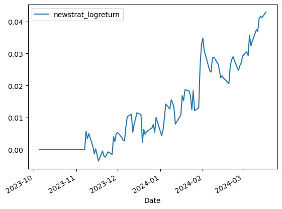

```python
#hdf.groupby('Date').sum()['strategy_logreturn'].cumsum().plot(legend=True)
#hdf.groupby('Date').sum()['equal_logreturn'].cumsum().plot(legend=True)
hdf.groupby('Date').sum()['newstrat_logreturn'].cumsum().plot(legend=True)
```

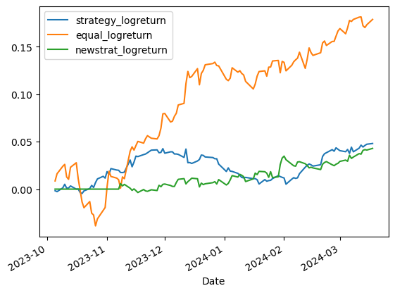

```python
hdf.groupby('Date').sum()['strategy_logreturn'].cumsum().plot(legend=True)
hdf.groupby('Date').sum()['equal_logreturn'].cumsum().plot(legend=True)
hdf.groupby('Date').sum()['newstrat_logreturn'].cumsum().plot(legend=True)
```